# ch2-assignment

Joe Dickerson

2025-08-29

Exercise 8

```r
getwd()
```

```
## [1] "C:/Users/Joe/git/r/phc6097"
```

```r
college <- read.csv("College.csv")
```

```r
rownames(college) <- college[, 1]
college <- college[, -1]
## View(college)
```

3. For part vi., I was most interested with the graduation rate variable, so I explored how the student faculty ratio, expenditure per student, and public vs. private school variables might influence graduation rate. The most clear finding is the box plot that shows a higher graduation rate among the private schools in the data. It also appears in our scatter plot of instructional expenditure per student that there is some relationship with higher spending and a higher graduation rate. I could not discern a relationship between student/faculty ratio and graduation rate, however.

```r
## i.
  summary(college)
```

```
##    Private               Apps           Accept          Enroll
##  Length:777         Min.   :   81   Min.   :   72   Min.   :  35
##  Class :character   1st Qu.:  776   1st Qu.:  604   1st Qu.: 242
##  Mode  :character   Median : 1558   Median : 1110   Median : 434
##                     Mean   : 3002   Mean   : 2019   Mean   : 780
##                     3rd Qu.: 3624   3rd Qu.: 2424   3rd Qu.: 902
##                     Max.   :48094   Max.   :26330   Max.   :6392
##    Top10perc       Top25perc      F.Undergrad     P.Undergrad
##  Min.   : 1.00   Min.   :  9.0   Min.   :  139   Min.   :    1.0
##  1st Qu.:15.00   1st Qu.: 41.0   1st Qu.:  992   1st Qu.:   95.0
##  Median :23.00   Median : 54.0   Median : 1707   Median :  353.0
##  Mean   :27.56   Mean   : 55.8   Mean   : 3700   Mean   :  855.3
##  3rd Qu.:35.00   3rd Qu.: 69.0   3rd Qu.: 4005   3rd Qu.:  967.0
##  Max.   :96.00   Max.   :100.0   Max.   :31643   Max.   :21836.0
##     Outstate       Room.Board       Books           Personal
##  Min.   : 2340   Min.   :1780   Min.   :  96.0   Min.   : 250
##  1st Qu.: 7320   1st Qu.:3597   1st Qu.: 470.0   1st Qu.: 850
##  Median : 9990   Median :4200   Median : 500.0   Median :1200
##  Mean   :10441   Mean   :4358   Mean   : 549.4   Mean   :1341
##  3rd Qu.:12925   3rd Qu.:5050   3rd Qu.: 600.0   3rd Qu.:1700
##  Max.   :21700   Max.   :8124   Max.   :2340.0   Max.   :6800
##       PhD            Terminal       S.F.Ratio      perc.alumni
##  Min.   :  8.00   Min.   : 24.0   Min.   : 2.50   Min.   : 0.00
##  1st Qu.: 62.00   1st Qu.: 71.0   1st Qu.:11.50   1st Qu.:13.00
##  Median : 75.00   Median : 82.0   Median :13.60   Median :21.00
##  Mean   : 72.66   Mean   : 79.7   Mean   :14.09   Mean   :22.74
##  3rd Qu.: 85.00   3rd Qu.: 92.0   3rd Qu.:16.50   3rd Qu.:31.00
##  Max.   :103.00   Max.   :100.0   Max.   :39.80   Max.   :64.00
##      Expend        Grad.Rate
##  Min.   : 3186   Min.   : 10.00
##  1st Qu.: 6751   1st Qu.: 53.00
##  Median : 8377   Median : 65.00
##  Mean   : 9660   Mean   : 65.46
##  3rd Qu.:10830   3rd Qu.: 78.00
##  Max.   :56233   Max.   :118.00
```

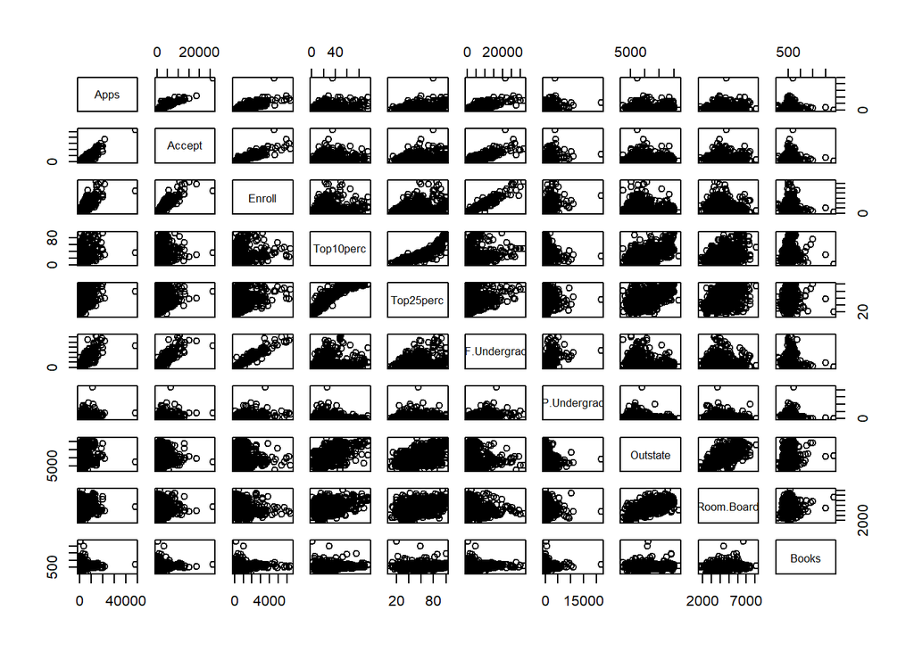

```r
## ii.
  pairs(college[,2:11])
```

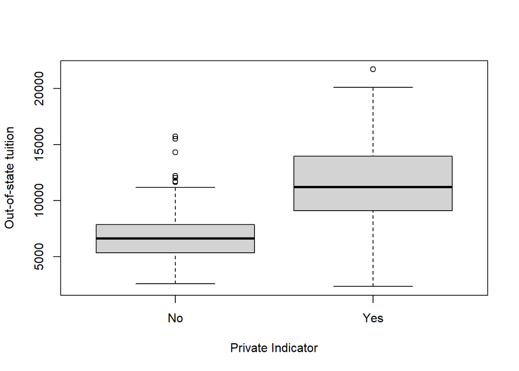

```r
## iii.
  plot(as.factor(college$Private), college$Outstate, xlab="Private Indicator", ylab="Out-of-state tuition")
```

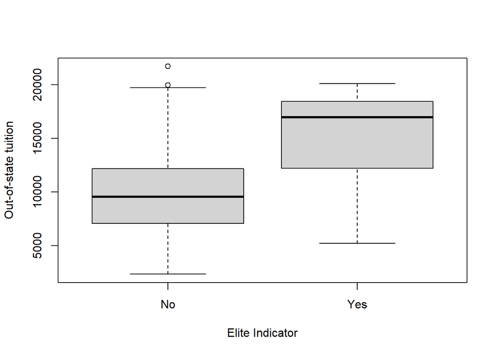

```r
## iv.
  Elite <- rep("No", nrow(college))
  Elite[college$Top10perc > 50] <- "Yes"
  Elite <- as.factor(Elite)
  college <- data.frame(college, Elite)

      ## summary(college)

  plot(as.factor(college$Elite), college$Outstate, xlab="Elite Indicator", ylab="Out-of-state tuition")
```

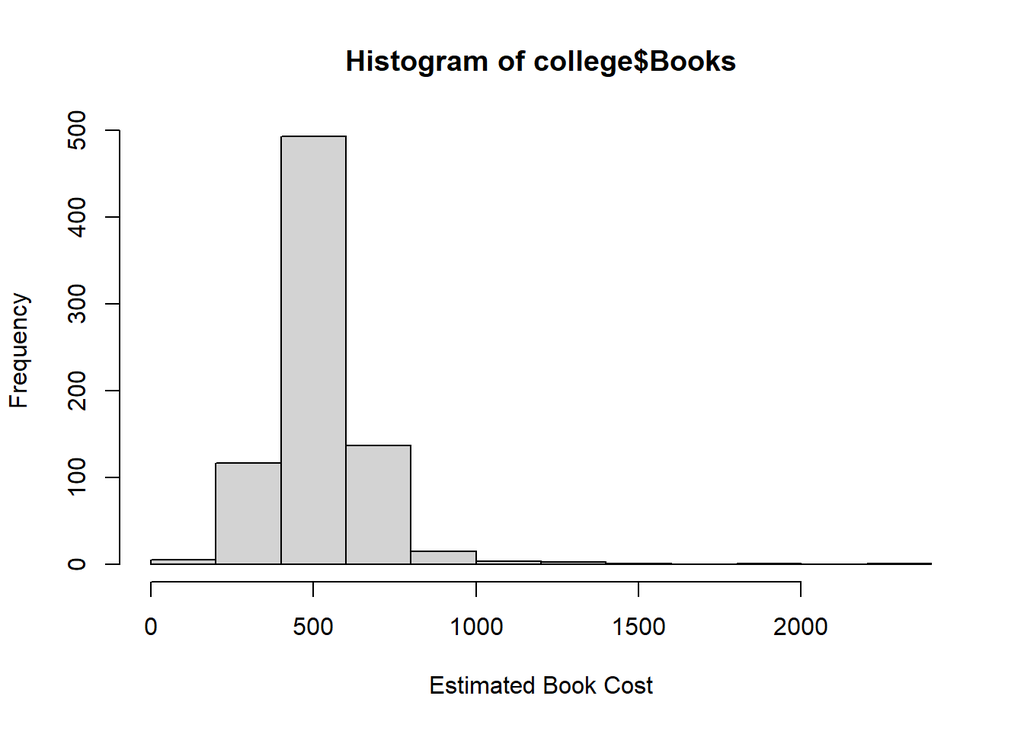

```r
## v.
  hist(college$Books, breaks = 12, xlab = "Estimated Book Cost")
```

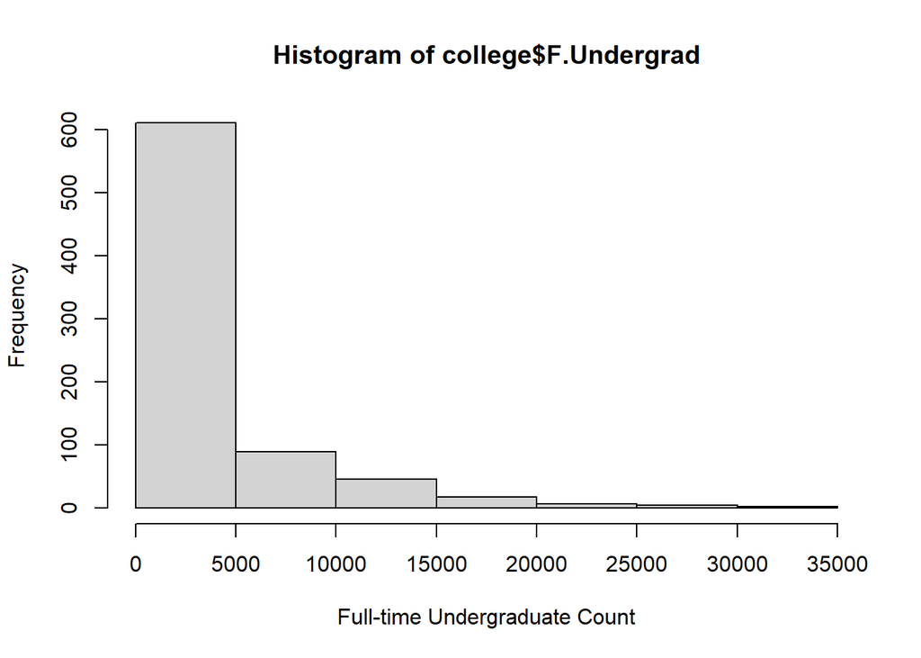

```r
  hist(college$F.Undergrad, breaks = 8, xlab = "Full-time Undergraduate Count")
```

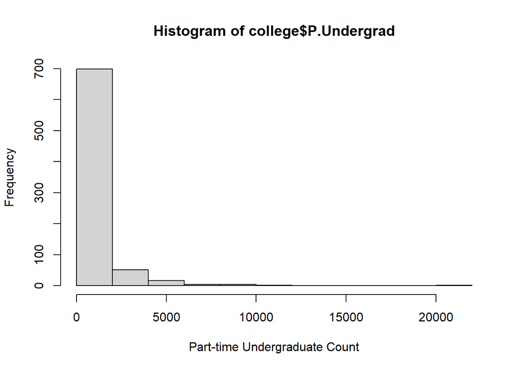

```r
  hist(college$P.Undergrad, breaks = 8, xlab = "Part-time Undergraduate Count")
```

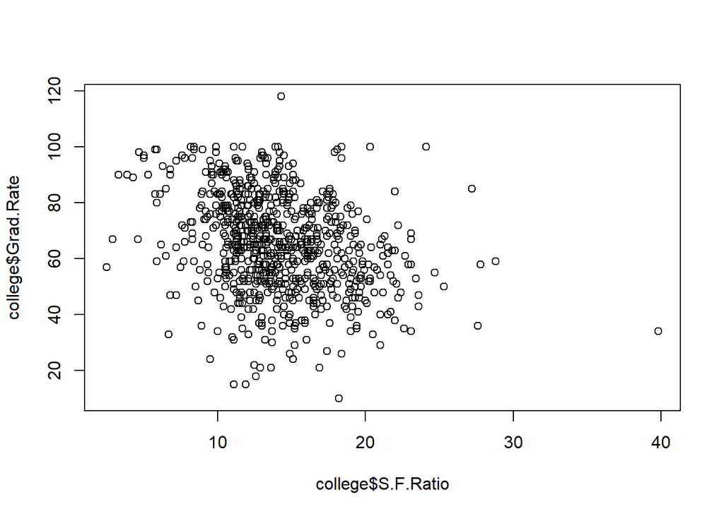

```r
## vi.
  plot(college$S.F.Ratio, college$Grad.Rate)
```

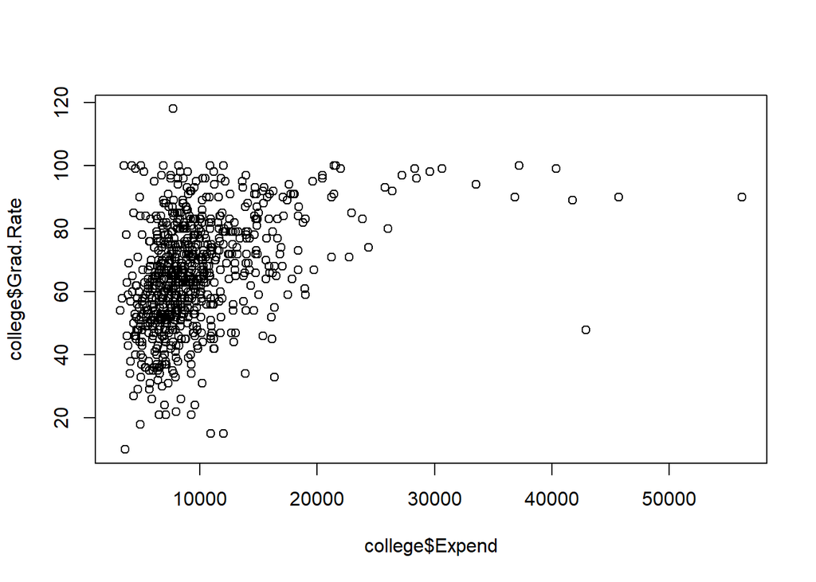

```r
  plot(college$Expend, college$Grad.Rate)
```

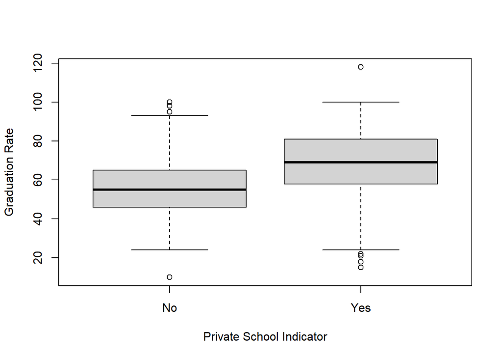

```r
  plot(as.factor(college$Private), college$Grad.Rate, xlab = "Private School Indicator", ylab = "Graduation Rate")
```

Exercise 9

1. Our quantitative predictors are MPG, displacement, horsepower, weight, and acceleration. Our qualitative predictors are cylinders, year, origin, and name.

```r
auto <- read.table("Auto.data", header = T, stringsAsFactors = T, na.strings = "?")
```

```r
range(auto$mpg)
```

```
## [1]  9.0 46.6
```

```r
range(auto$displacement)
```

```
## [1]  68 455
```

```r
range(auto$horsepower, na.rm = T)
```

```
## [1]  46 230
```

```r
range(auto$weight)
```

```
## [1] 1613 5140
```

```r
range(auto$acceleration)
```

```
## [1]  8.0 24.8
```

```r
print("Means:")
```

```
## [1] "Means:"
```

```r
mean(auto$mpg)
```

```
## [1] 23.51587
```

```r
mean(auto$displacement)
```

```
## [1] 193.5327
```

```r
mean(auto$horsepower, na.rm = T)
```

```
## [1] 104.4694
```

```r
mean(auto$weight)
```

```
## [1] 2970.262
```

```r
mean(auto$acceleration)
```

```
## [1] 15.55567
```

```r
print("Standard deviations:")
```

```
## [1] "Standard deviations:"
```

```r
sd(auto$mpg)
```

```
## [1] 7.825804
```

```r
sd(auto$displacement)
```

```
## [1] 104.3796
```

```r
sd(auto$horsepower, na.rm = T)
```

```
## [1] 38.49116
```

```r
sd(auto$weight)
```

```
## [1] 847.9041
```

```r
sd(auto$acceleration)
```

```
## [1] 2.749995
```

```r
auto2 <- auto[-(10:85),]

print("Ranges:")
```

```
## [1] "Ranges:"
```

```r
range(auto2$mpg)
```

```
## [1] 11.0 46.6
```

```r
range(auto2$displacement)
```

```
## [1]  68 455
```

```r
range(auto2$horsepower, na.rm = T)
```

```
## [1]  46 230
```

```r
range(auto2$weight)
```

```
## [1] 1649 4997
```

```r
range(auto2$acceleration)
```

```
## [1]  8.5 24.8
```

```r
print("Means:")
```

```
## [1] "Means:"
```

```r
mean(auto2$mpg)
```

```
## [1] 24.43863
```

```r
mean(auto2$displacement)
```

```
## [1] 187.0498
```

```r
mean(auto2$horsepower, na.rm = T)
```

```
## [1] 100.9558
```

```r
mean(auto2$weight)
```

```
## [1] 2933.963
```

```r
mean(auto2$acceleration)
```

```
## [1] 15.72305
```

```r
print("Standard deviations:")
```

```
## [1] "Standard deviations:"
```

```r
sd(auto2$mpg)
```

```
## [1] 7.908184
```

```r
sd(auto2$displacement)
```

```
## [1] 99.63539
```

```r
sd(auto2$horsepower, na.rm = T)
```

```
## [1] 35.89557
```

```r
sd(auto2$weight)
```

```
## [1] 810.6429
```

```r
sd(auto2$acceleration)
```

```
## [1] 2.680514
```

5. For my first plot, I wanted to see if there is a relationship between the weight of the vehicle and how much horsepower it has, and I found there is a connection between the two variables. As weight goes up, so does the horsepower. This makes sense as the engine is perhaps the heaviest part of the vehicle, and it is only worthwhile to make the engine heavier if it is also going to make it more powerful.

My second plot makes a similar comparison, but instead of horsepower, we are looking at how the weight affects the miles per gallon. As expected, as the weight goes up, the mpg goes down. The sacrifice for power is efficiency.

I used ggplot2 to make these graphs for the added regression line.

```r
library(tidyverse)
```

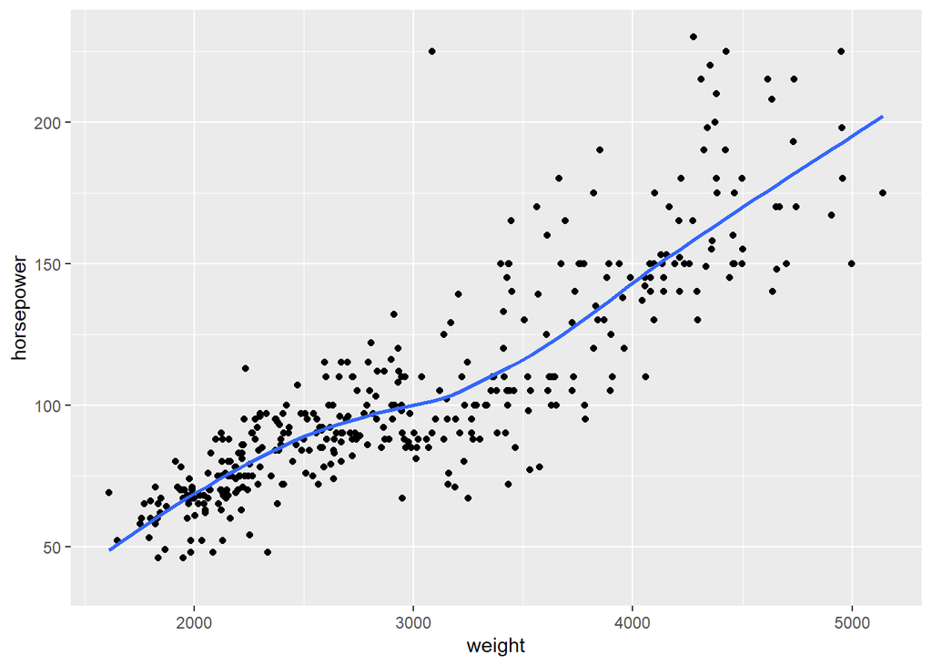

```r
auto %>%
  ggplot(aes(x = weight, y = horsepower)) +
  geom_point() +
  geom_smooth(fill = NA)
```

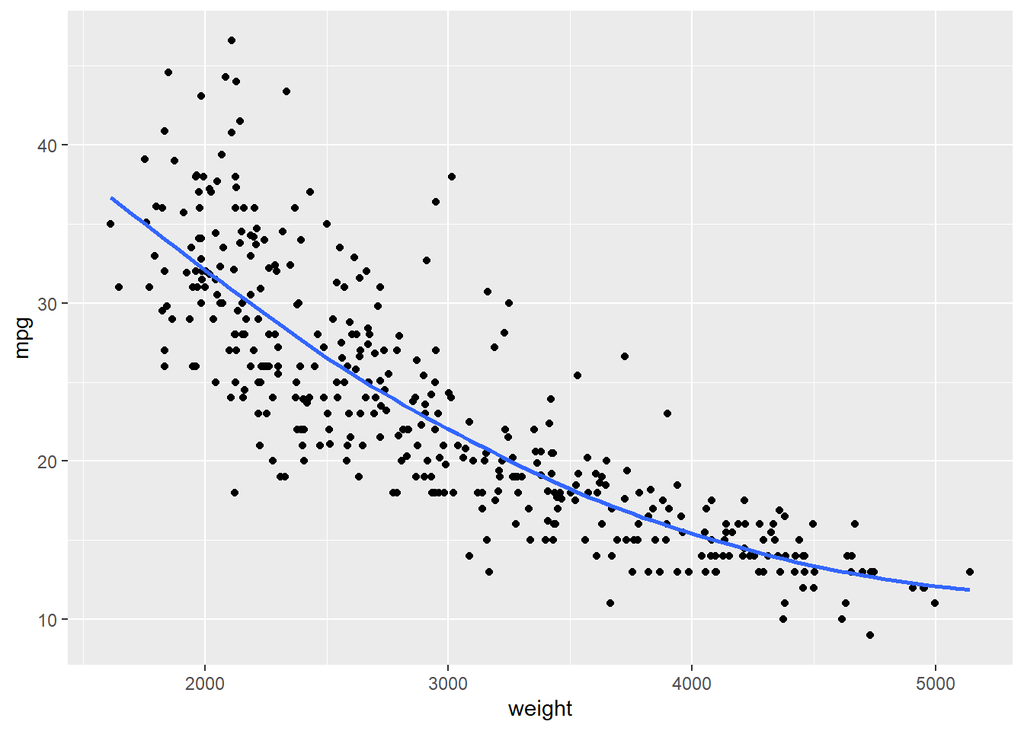

```r
auto %>%
  ggplot(aes(x = weight, y = mpg)) +
  geom_point() +
  geom_smooth(fill = NA)
```

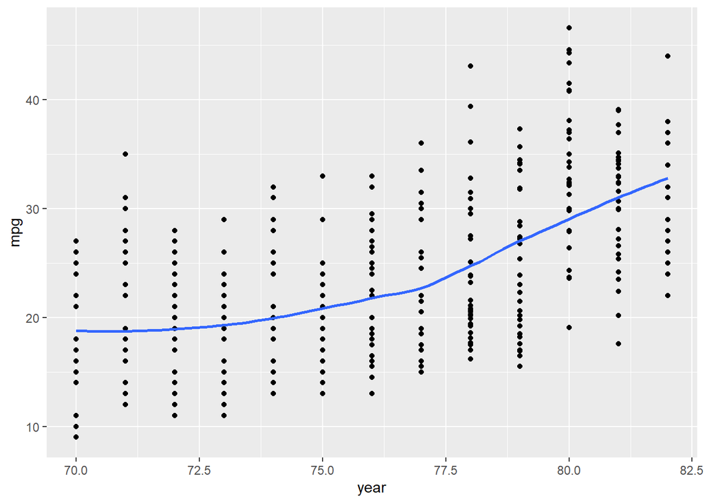

```r
auto %>%
  ggplot(aes(x = year, y = mpg)) +
  geom_point() +
  geom_smooth(fill = NA)
```

6. Coincidentally, I have already looked at mpg against the weight and year already, and we saw a clear relationship between weight and mpg (higher weight resulted in a lower mpg). So, I have also made graphs to compare the displacement, acceleration, and horsepower to mpg. We see a strong relationship between displacement and mpg, and between horsepower and mpg. Mileage goes down as displacement and horsepower go up. However, we see a weaker relationship between acceleration and mpg. As I looked in the previous question, it does seem like the categorical variable of year does influence the mpg, probably because as technology improved and people wanted to save more money on fuel, auto manufacturers responded with vehicles that get better mileage.

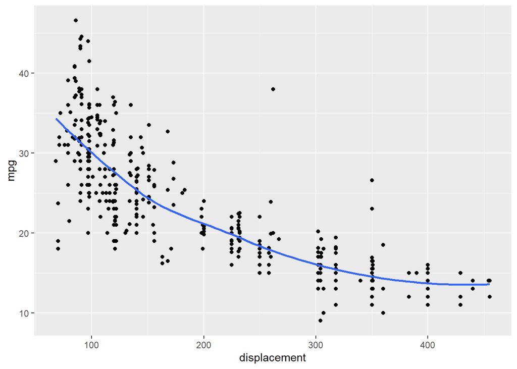

```r
auto %>%
  ggplot(aes(x = displacement, y = mpg)) +
  geom_point() +
  geom_smooth(fill = NA)
```

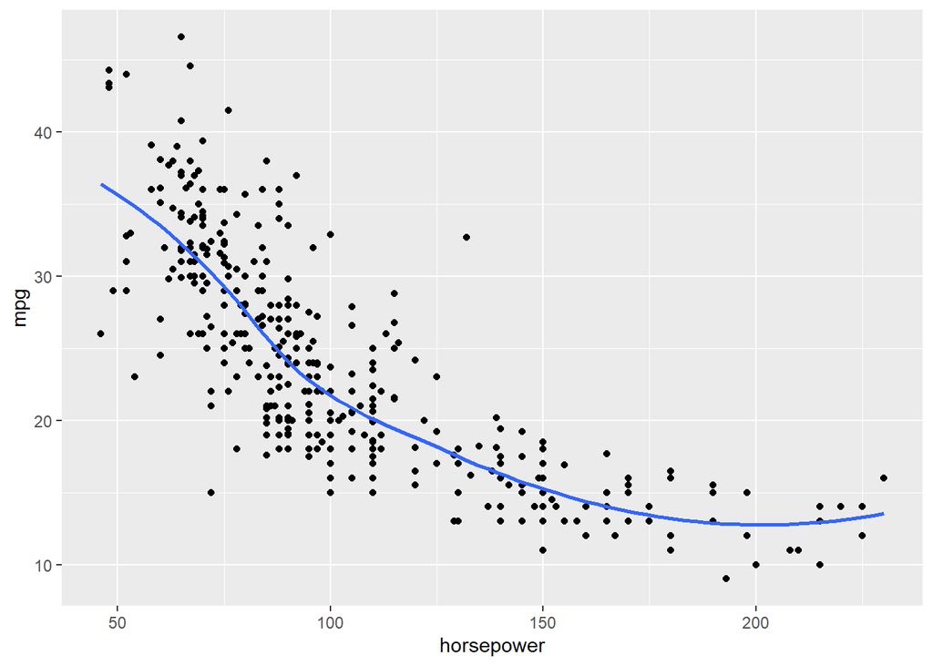

```r
auto %>%
  ggplot(aes(x = horsepower, y = mpg)) +
  geom_point() +
  geom_smooth(fill = NA)
```

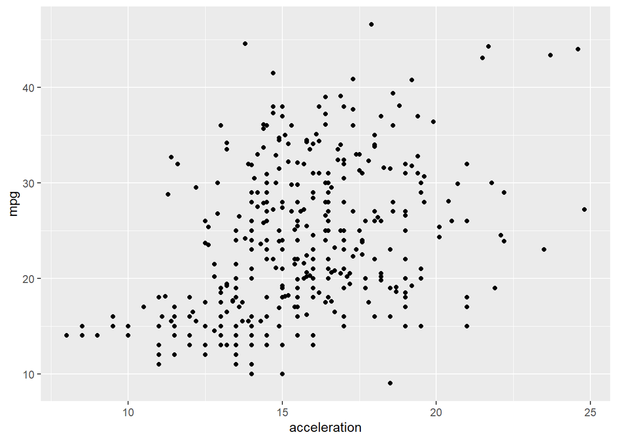

```r
auto %>%
  ggplot(aes(x = acceleration, y = mpg)) +
  geom_point()
```